# Performance ranking of flexible species distribution modelling methods does not change with spatial cross-validation. Global Ecology and Biogeography

Appendix S1

Roozbeh Valavi https://github.com/rvalavi (The University of Melbourne, Australia)https://ecosystemforest.unimelb.edu.au/ , Jane Elith (The University of Melbourne, Australia)https://ecosystemforest.unimelb.edu.au/ , José J. Lahoz-Monfort (The University of Melbourne, Australia)https://ecosystemforest.unimelb.edu.au/ , Gurutzeta Guillera-Arroita (The University of Melbourne, Australia)https://ecosystemforest.unimelb.edu.au/  
2022-06-14

Appendix S1 for *Valavi, R., Elith, J., Lahos-Monfort, J.J., Guillera-Arroita, G. (2022) Performance ranking of flexible species distribution modelling methods does not change with spatial cross-validation. Global Ecology and Biogeography.*

## Top rank models in different evaluations

In the main text, the mean performance and the average rank of performance metrics (i.e., $AUC_{ROC}$, $AUC_{PRG}$, and COR) were used to assess and compare models. However, this approach does not show how frequent a model was the top model or whether it was among the top 2-3 models. Here we calculated the percentage of the species (171 species in our study) that a model was in the top 1, top 2, or top 3 models (Figures 1 and 2). For example, for $AUC_{ROC}$ in the random partitioning (Figure 1), the Ensemble model was in the top 3 models for 63.7% of the species.

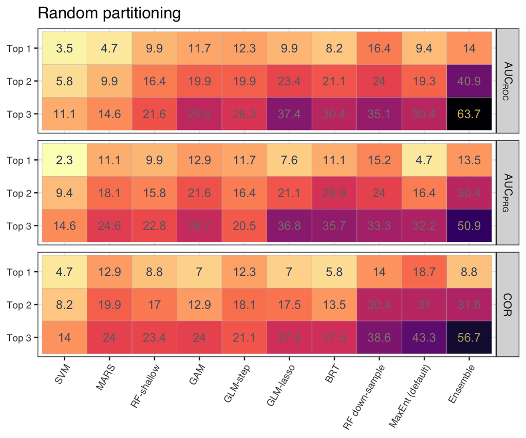

Figure 1: Top rank models in random partitioning.

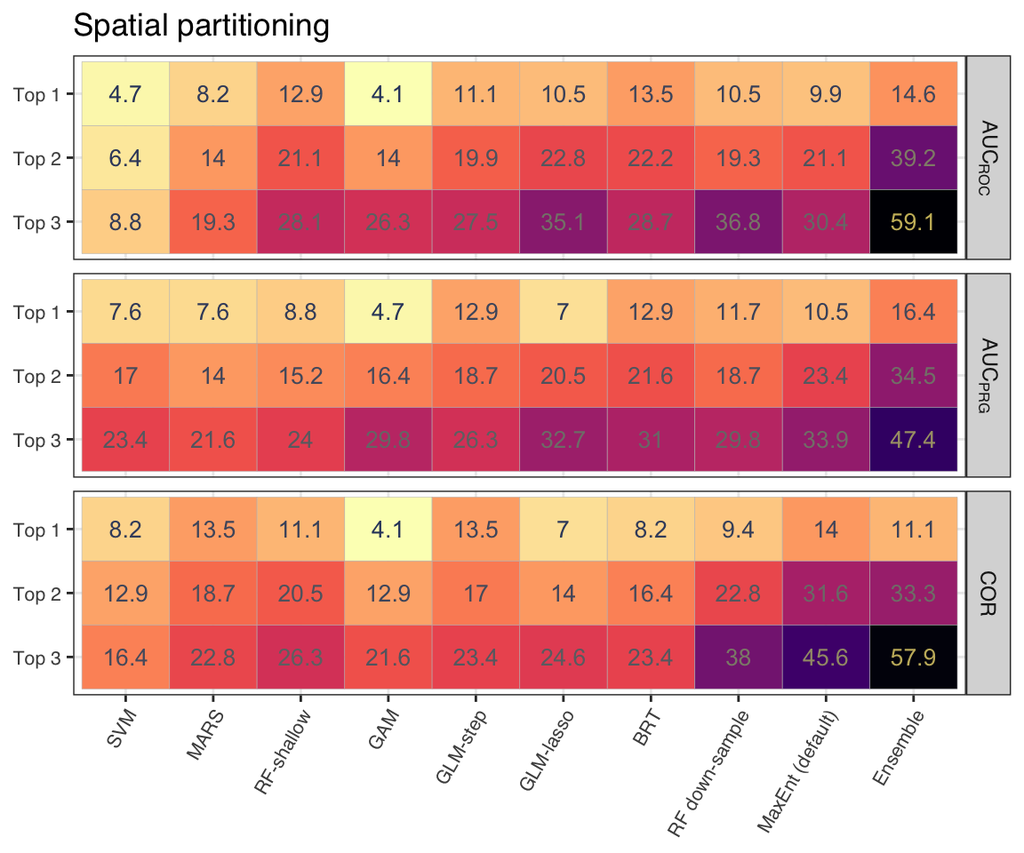

Figure 2: Top rank models in spatial partitioning

Notice that all methods performed the best (top 1) for at least a few species in both random and spatial partitioning. A noticeable result here is that some models like GLM-step, MARS, or RF-shallow are average performers overall, predicting some species better than our top models (for example, GLM-step vs BRT in the top 1 models for random partitioning; or RF-shallow vs RF down-sample or MaxEnt in top 1 model for spatial partitioning). See [Valavi *et al.* (202)](https://esajournals.onlinelibrary.wiley.com/doi/full/10.1002/ecm.1486) for further explanation for the same models fitted on the NCEAS data.

## Rank of the Ensemble vs its component models

Here we calculated the same plots but only for the Ensemble model and its component models i.e, GLM-lasso, GAM, MaxEnt (default), BRT, and RF down-sample (Figure 3). The Ensemble appeared in the top 2 and 3 models for more species than its component in both random and spatial partitioning. For top 1 models, it was only best for $AUC_{ROC}$ (along with RF down-sample) in random partitioning, but the best for both AUCs and the second-best for COR in spatial partitioning. The fact that Ensemble appears better than its component in spatial partitioning might be a piece of evidence that ensembling of tuned models can lead to better generalization.

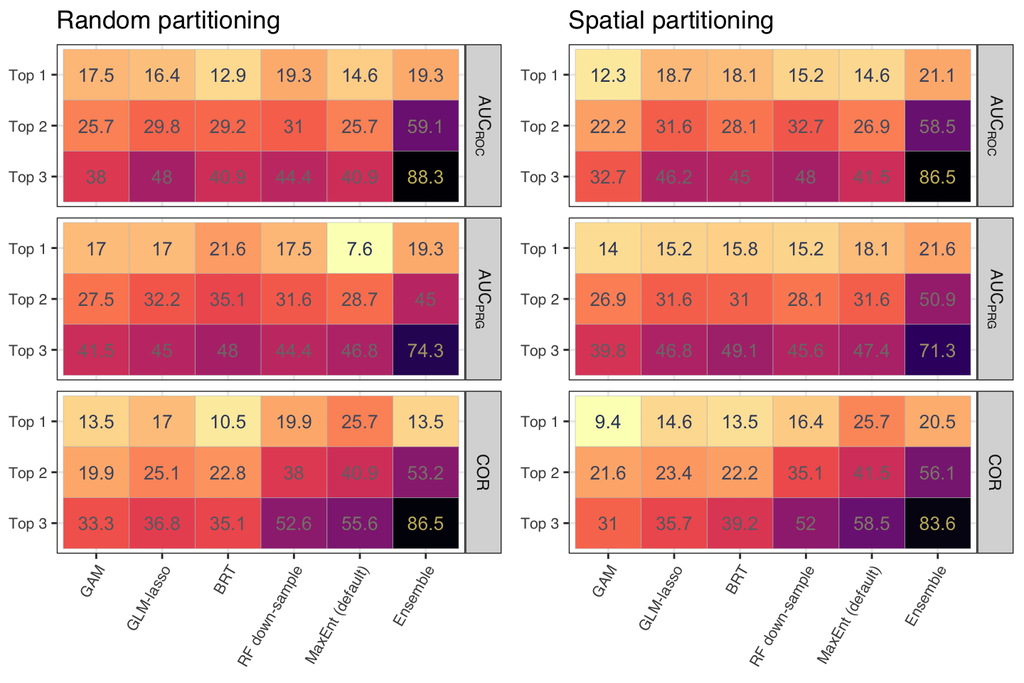

Figure 3: Top rank model among Ensemble and its component models.

To assess whether the Ensemble improves with respect to the best model in the set or not, we did further exploration and realised that in all cases of “Top 1” Ensemble actually outperformed its component (rather than being just as good as the best model in its components). This could be an indication that the ensemble gains by combining “complementary” predictions.

## Difference from average

To further highlight the difference between the performance of models, we calculated the difference between $AUC_{ROC}$ of each model from the average $AUC_{ROC}$ of all models for one single species.

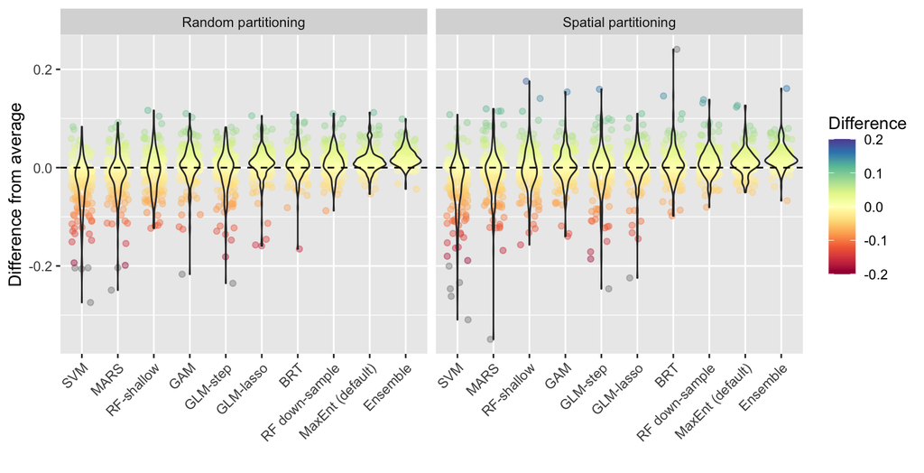

Figure 4: Diffrence from average $AUC_{ROC}$.

The zero line (dashed line in y-axis) in Figure 4 shows no difference with the mean $AUC_{ROC}$. The positive values show prediction with higher $AUC_{ROC}$ than the average for each model/specie, and vice versa. Each point represents an $AUC_{ROC}$ of a model for one species.  
SVM and MARS were mostly below average, but MaxEnt and Ensemble are mostly above average.

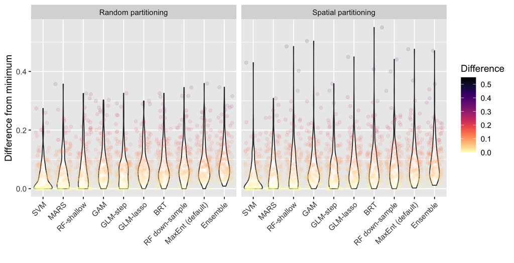

Figure 5: Difference from the minimum $AUC_{ROC}$.

Figure 5 demonstrate the difference in $AUC_{ROC}$ of each model with the worst model (model with the lowest $AUC_{ROC}$) for each species. higher values means better performance.

## Interactions in BRT and MaxEnt

To assess the impacts of interactions in flexible models, we compare two of our top methods, BRT and MaxEnt, with and without interactions. We implemented a BRT model with a limited tree-complexity of `1` also known as **stump**. The main difference between the BRT-stump and the default BRT (with tree-complexity 1 or 5) is that the default BRT can fit a higher level of interaction between the covariates. The implemented BRT model here (Elith *et al.* 2008) utilized internal cross-validation to fund the right complexity for the model. Thus, by limiting tree-complexity to 1, the model adds more trees to find a similar balance in the fitted model as the BRT with tree-complexity 5.  
MaxEnt is also presented as two variants here, the MaxEnt with forced LQ features and one with LQP features. The main difference between these two is that MaxEnt-LQP accommodates interaction as the product of the linear features.

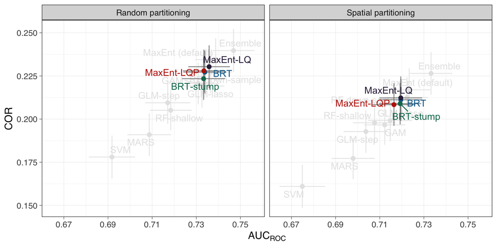

Figure 6: Perfromance of implementation of BRT and MaxEnt with forced limited flexibility.

There is a small and insignificant difference between the performance of the BRT vs BRT-stump and between MaxEnt-LQP vs MaxEnt-LQ. The MaxEnt-LQP had a lower $AUC_{ROC}$ and COR in both partitioning methods which could be because forced interaction in the model is too complex for some species with a very low number of presence records. On the other hand, BRT performed better than BRT-stump as the model uses cross-validation to regulate the appropriate amount of complexity with different parameter sets.

## Extraploation in testing blocks

It is useful to know whether extrapolation happens when models are used to predict to spatially separated points. Extrapolation occurs when the testing/predicting sites have environmental values outside of the range of environmental conditions used in the training samples. To measure the amount of extrapolation in testing sites we used Multivariate Environmental Similarity Surface (MESS) introduced by Elith *et al.* (2010). We used the `mess` function in the **dismo** R package for computing the MESS values for the presence-absence of evaluation data, using the training presence-TGB as the reference sites. We used only continuous covariates for this. For more explanation on MESS, see Elith *et al.* (2010).

In Figure 7, we summed the number of testing points with extrapolation (negative MESS values) for each species. This gives a good sense of whether species from a region enforce extrapolation to the models.

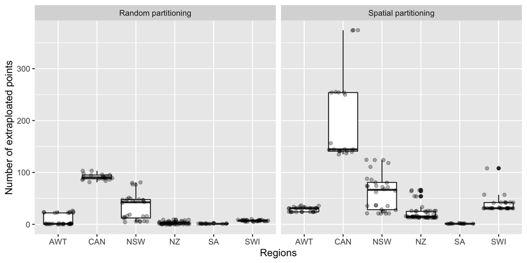

Figure 7: The sum of extrapolated points of each species in each region.

Figure 8 shows the number of extrapolated sites with spatial partitioning compare to random partitioning. You can see a more extrapolation was enforced in spatial partitioning.

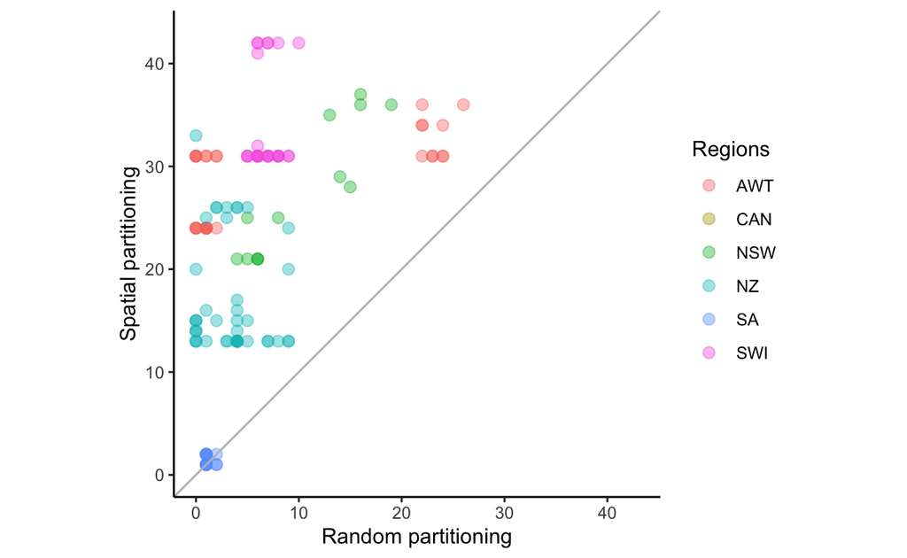

Figure 8: The sum of the number of extrapolated points in each species in random vs spatial partitioning.

## Statistical test for random partitioning

Here the statistical test on the differences between models in random partitioning are presented (Figure 9). The plots are $AUC_{ROC}$, $AUC_{PRG}$, and COR from top to bottom, respectively. The number on the top of the x-axis shows the range of the ranks of the models. The rank of each model is indicated by the thin line connected to the scale and the lines (models) that are connected by the horizontal thick line are not statistically different at 0.05 significance level.

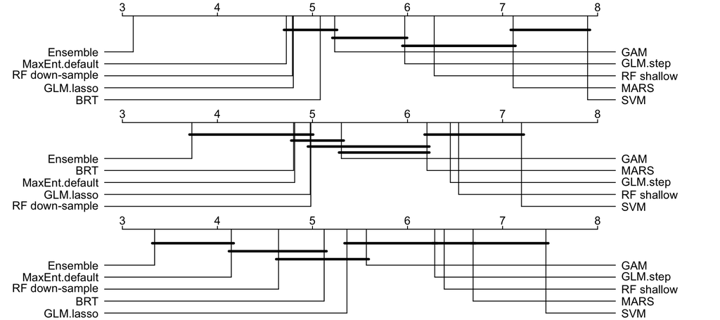

Figure 9: The average rank and statistical difference of the models in random partitioning.

## Statistical test for MaxEnt models in spatial partitioning

Here the statistical test for MaxEnt models are presented. The Friedman’s Aligned Rank test for $AUC_{PRG}$ is not significant indicating no significant difference in MaxEnt variant in this statistics. Thus only the result of pairwise test for $AUC_{ROC}$ and $COR$ are plotted (Figure 10). In general the differences between these models are insignificant.

```
    Friedman's Aligned Rank Test for Multiple Comparisons

data:  roc_maxents
T = 13.704, df = 4, p-value = 0.008303
```

```
    Friedman's Aligned Rank Test for Multiple Comparisons

data:  prg_maxents
T = 7.7372, df = 4, p-value = 0.1017
```

```
    Friedman's Aligned Rank Test for Multiple Comparisons

data:  cor_maxents
T = 16.766, df = 4, p-value = 0.002146
```

The plots in Figure 10 are $AUC_{ROC}$ (top) and COR (bottom). The number on the top of the x-axis shows the range of the ranks of the models. The rank of each model is indicated by the thin line connected to the scale and the lines (models) that are connected by the horizontal thick line are not statistically different at 0.05 significance level.

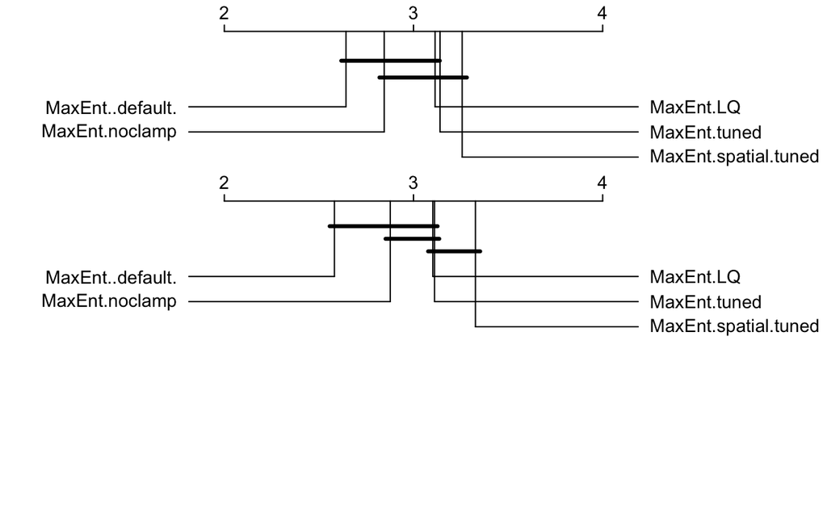

Figure 10: The average rank and statistical difference of the MaxEnt models in spatial partitioning.

## Modelling methods parameters

A summary of model implementation settings are presented in Table 1. The “parameters” column shows model arguments in R programming that are selected in the modelling process. The “value” column shows the value or ranges of values selected for model fitting and tuning for each R function. The “weighted” column specifies if weighting was used. With the weights, background points were down-weighted to have a total (summed) weight equal to the total number of the presences (Valavi *et al.* 2022). All models are fitted in R v4.0.0.  
Some of the models accept weights. GAM, GLMs, and BRT use case weights (i.e., there is a weight for each training sample), and SVM utilizes class weights (i.e., there is a weight for each class; here presence and background samples are the two classes so there are only two weights). The weights are generated by giving a weight of 1 to every presence point and giving the weights to the background in a way that the sum of the weights for the presence and background are equal. For class weights in SVM, an inverse proportional weight was used.

Table 1: Parameters used for implementing different modes.

| Method | Parameter | Values | Description | R.packages |
| --- | --- | --- | --- | --- |
| GAM | method | REML |  smoothing parameter estimation method | mgcv v1.8-32 |
|  | k | 10 | the number of basis functions (for creating smoothing terms) specifies the possible maximum effective degree of freedom |  |
| GLM-step * | direction | both | step-selection direction (forward & backward) based on AIC | gam v1.20 |
| GLM-lasso * | alpha | 1 | lasso penalty | glmnet v4.0-2 |
| MARS | nprune | 2 to 20 | number of terms | earth v5.1.2 |
|  | degree | 1 | degree of interaction (1 means no interaction allowed) |  |
| MaxEnt (default) | args | nothreshold | auto select feature and exclude threshold feature | dismo v1.1-4 and maxent.jar v3.4.4 |
|  | betamultiplier | 1 | regularisation multiplier |  |
| BRT | tree.complexity | 1 or 5 |  depth of individual trees - two options depending on sample size | dismo v1.1-4 and gbm v2.1.5 |
|  | learning.rate | 0.001 | shrinkage or the weight applied to individual trees |  |
|  | bag.fraction | 0.75 | proportion of observations sampled to train each tree |  |
|  | n.folds | 5 | number of cross-validation folds |  |
| RF-shallow | mtry | sqrt(p) | number of variables randomly selected at each split | ranger v0.12.1 |
|  | num.trees | 2000 | number of trees |  |
|  | splitrule | “hellinger” | tree splitting criterion |  |
|  | max.depth | 2 | maximum depth of each tree (forcing shallow trees) |  |
|  | probability | TRUE | fitting probability trees |  |
| RF down-sampled | mtry | sqrt(p) | number of variables randomly selected at each split | randomForest v4.6-14 |
|  | sampsize | n. presences | number of bootstrap samples taken from each class |  |
|  | ntrees | 1000 | number of trees |  |
| SVM | kernel | radial | radial basis kernel | e1071 v1.7-3 |
| Ensemble |  |  | Rescale and average of individual modes implemented here: GAM, GLM-lasso, MaxEnt, BRT and RF down-sampled |  |

- GLM-step and GLM-lasso were fitted allowing linear and quadratic terms only, with no interactions.

## Parameters of MaxEnt variants

Table 2: Parameters of MaxEnt model in different MaxEnt variants.

| Model | Parameter | Value | Description |
| --- | --- | --- | --- |
| MaxEnt (default) | betamultiplier | 1 | regularization multiplier |
|  | args | nothreshold | auto select feature and exclude threshold feature |
| MaxEnt noclamp |  |  | the same as MaxEnt (default) with clammping set to off for prediction |
| MaxEnt LQ | betamultiplier | 1 | regularization multiplier |
|  | feature types | LQ | transformations of input covariates. L: linear, Q: quadratic |
| MaxEnt tuned and spatial-tuned | betamultiplier | 0.5, 1, 2, 3, 4 | regularization multiplier |
|  | feature types | L, LQ, H, LQH, LQHP | transformations of input covariates. L: linear, Q: quadratic, H: hinge, P: product |

## Code and data availability

You can find the data in `disdat` R package and the TGB data in Elith *et al.* (2020). To run the models, you can use the codes and data provide in OSF repository and run the code. However, because you probably have different R package version than the one we used ion our analysis the results will not be reproducible (still will be similar). To make sure reproducibility is maintained we use Docker technology and provided the `Dockerfile` (and pre-built `docker image`) so you can have the same R packages and system as we used in our analysis. A third option would be just use the `revn.lock` file and retrieve the package versions in you local system with `renv` package.

Here we explain how to use Dockers for creating a virtual system to reproduce our results.

### Installation

Docker can be installed on different platforms. You can find the instruction for installing docker on different operating systems visit [docker website](https://docs.docker.com/get-docker/).

### Creating the image

Follow the instruction below to create the docker image with RSudio installed and all the R and system packages required for running our analysis.

The following command are terminal commands.

### Clone this repository

You need to have [`git`](https://git-scm.com/) installed on your system.

```bash
git clone https://github.com/rvalavi/SDM-Spatial-Validation.git
```

### Build the docker image

In Linux system you might need to use `sudo` command before `docker` commands. The following command may take a while!

```bash
cd SDM-Spatial-Validation

docker build -t rvalavi:4.0 .
```

Wait until the build is complete. Then check to see the images is created.

```bash
docker images
```

You should see `rvalavi` with TAG 4.0 listed as a docker image.

### Run the docker container

After the image is created, you need to run a container to get access to the RStudio and packages. The docker container is a live instance of the image and you can use and even make change to it. This however will not changes the image. Use the following command to run a container.

```bash
docker run --name rstudio -p 8787:8787 -e PASSWORD=123 -e USER=rstudio -d rvalavi:4.0
```

This code has several components:  
`--name`: name of the container  
`-p`: port on which container is running. We use this to connect to rstudio  
`-e USER` and `-e PASSWORD`: user and password for the rstudio server  
`-v`: mapping a directory in the local system to a directory in the container. This will allow you to save the generated files and code in local drive and also access to code/data inside your system.  
`-d`: run the container in the background  
`rvalavi:4.0`: name and tag of the docker image

### Run RStudio server

Open an Internet browser and go to `localhost:8787` to open RStudio. Use the user and password you specified in the previous step (here user is “rstudio” and password is “123”) to open RStudio.

[figure not shown]

You can run models by running the `R/nceas_modelling.R` script.

## Covariates of each region

Table **3 to 8** show the environmental covariates used in each region. These are the variables that do not have a pairwise correlation of more than 0.8. You can find a complete list of variables with more details in Elith *et al.* (2020), and in the help of the [`disdat`](https://CRAN.R-project.org/package=disdat) R package.

Table 3: Environmental vartiables for AWT region.

| Code | Description | Units | Type |
| --- | --- | --- | --- |
| bc04 | Temperature seasonality | NA | Continuous |
| bc05 | Max. temperature of warmest period | ˚C | Continuous |
| bc06 | Min. temperature of coldest period. | ˚C | Continuous |
| bc12 | Annual precipitation | mm | Continuous |
| bc15 | Precipitation seasonality | NA | Continuous |
| slope | Mean slope (derived from 9 second spatial resolution elevation data) | percent | Continuous |
| topo | Topographic position | NA | Continuous |
| tri | Terrain ruggedness index | NA | Continuous |

Table 4: Environmental vartiables for CAN region.

| Code | Description | Units | Type |
| --- | --- | --- | --- |
| alt | Digital elevation | m | Continuous |
| asp2 | Aspect – ranges from -1 to 1 (sin transformation) | number (dimensionless unit) | Continuous |
| ontprec | Annual Precipitation | mm | Continuous |
| ontslp | Slope | degrees | Continuous |
| onttemp | Annual mean temperature | ˚C * 10 | Continuous |
| ontveg | Vegetation, from Ontario Land Cover Database (OLC) vegetation map, derived from a mosaic of Landsat images. | number (dimensionless unit) | Categorical |
| watdist | Distance from Hudson Bay | m | Continuous |

Table 5: Environmental vartiables for NSW region.

| Code | Description | Units | Type |
| --- | --- | --- | --- |
| cti | compound topographic index- a quantification of the position of a site in the local landscape | number (dimensionless index) | Continous |
| disturb | disturbance (clearing, logging etc) | number (ordinal) | Continous |
| mi | moisture index. | number (dimensionless index) | Continous |
| rainann | mean annual rainfall | Mm | Continous |
| raindq | mean rainfall of the driest quarter | Mm | Continous |
| rugged | ruggedness | number (dimensionless index) | Continous |
| soildepth | mean soil depth | m *1000 | Continous |
| soilfert | soil fertility | number (ordinal) | Continous |
| solrad | annual mean solar radiation | MJm-2 day-1 * 10 | Continous |
| tempann | annual mean temperature | °C * 10 | Continous |
| topo | topographic position | m | Continous |

Table 6: Environmental vartiables for NZ region.

| Code | Description | Units | Type |
| --- | --- | --- | --- |
| age | soil parent material: age since last major rejuvenation | number (category) | Categorical |
| deficit | mean October vapor pressure deficit at 0900 hours | kPa | Continous |
| hillshade | surrogate for slope and aspect | number (dimensionless index) | Continous |
| mas | mean annual solar radiation | MJm^-2 day^-1 * 100 | Continous |
| mat | mean annual temperature | °C * 10 | Continous |
| r2pet | average monthly ratio of potential evapotranspiration | number (dimensionless index) | Continous |
| slope | slope | degrees | Continous |
| sseas | solar radiation seasonality | number (dimensionless index) | Continous |
| toxicats | toxic cations in soil | number (category) | Categorical |
| tseas | temperature seasonality | number (dimensionless index) | Continous |
| vpd | annual vapor pressure deficit | kPa | Continous |

Table 7: Environmental vartiables for SA region.

| Code | Description | Units | Type |
| --- | --- | --- | --- |
| sabio2 | mean diurnal range (mean of monthly (max temp - min temp)) | ˚C*10 | Continous |
| sabio4 | temperature seasonality (standard deviation *100) | number (dimensionless index) | Continous |
| sabio5 | max temperature of warmest month | ˚C*10 | Continous |
| sabio6 | min temperature of coldest month | ˚C*10 | Continous |
| sabio12 | annual precipitation | mm | Continous |
| sabio15 | precipitation seasonality (coefficient of variation) | number (dimensionless index) | Continous |
| sabio17 | precipitation of driest quarter | mm | Continous |
| sabio18 | precipitation of warmest quarter | mm | Continous |

Table 8: Environmental vartiables for SWI region.

| Code | Description | Units | Type |
| --- | --- | --- | --- |
| BCC | broadleaved continuous cover | % cover | Continous |
| CALC | bedrock strictly calcareous vs other type | 1 (present) or 0 (absent) | Categorical |
| CCC | coniferous continuous cover | % cover | Continous |
| DDEG | growing degree-days above the threshold of 0°C | °C * days | Continous |
| NUTRI | soil nutrients index | D mval/cm2 | Continous |
| PDAY | number of days with rainfall > 1 mm | ndays | Continous |
| PRECYY | average yearly precipitation sum | mm | Continous |
| SFROYY | summer frost frequency – number of days | days | Continous |
| SLOPE | slope | degrees x 10 | Continous |
| SRADYY | potential yearly global radiation (daily average) | kJm-2day-1 | Continous |
| SWB | site water balance | mm | Continous |
| TOPO | topographic position | number (dimensionless index) | Continous |

## List of species used in modelling

For creating spatial blocks some species did not have enough data to fit and evaluate models. Here, we provide the list of species we used in our study.

Table 9: List of species used for modelling. PO is the number of presence-only recods in the tarining dataset, TGBs is the number of Target-Group-Background samples, and Presence/Absence are the number of records in the evaluation dataset.

|  | Region | Species | PO | TGBs | Presence | Absence |
| --- | --- | --- | --- | --- | --- | --- |
| 1 | AWT | awt01 | 178 | 714 | 92 | 248 |
| 2 | AWT | awt02 | 149 | 714 | 105 | 235 |
| 3 | AWT | awt03 | 219 | 714 | 129 | 211 |
| 4 | AWT | awt04 | 216 | 714 | 158 | 182 |
| 5 | AWT | awt05 | 114 | 714 | 47 | 293 |
| 6 | AWT | awt06 | 265 | 714 | 187 | 153 |
| 7 | AWT | awt07 | 158 | 714 | 81 | 259 |
| 8 | AWT | awt08 | 231 | 714 | 137 | 203 |
| 9 | AWT | awt09 | 112 | 714 | 46 | 294 |
| 10 | AWT | awt10 | 122 | 714 | 102 | 238 |
| 11 | AWT | awt11 | 82 | 714 | 13 | 327 |
| 12 | AWT | awt12 | 32 | 714 | 16 | 324 |
| 13 | AWT | awt13 | 122 | 714 | 102 | 238 |
| 14 | AWT | awt14 | 99 | 714 | 65 | 275 |
| 15 | AWT | awt15 | 254 | 714 | 214 | 126 |
| 16 | AWT | awt16 | 144 | 714 | 64 | 276 |
| 17 | AWT | awt17 | 184 | 714 | 103 | 237 |
| 18 | AWT | awt18 | 242 | 714 | 137 | 203 |
| 19 | AWT | awt19 | 78 | 714 | 64 | 276 |
| 20 | AWT | awt20 | 104 | 714 | 80 | 260 |
| 21 | AWT | awt21 | 17 | 379 | 20 | 82 |
| 22 | AWT | awt25 | 12 | 379 | 24 | 78 |
| 23 | AWT | awt27 | 41 | 379 | 27 | 75 |
| 24 | AWT | awt31 | 14 | 379 | 62 | 40 |
| 25 | AWT | awt33 | 18 | 379 | 24 | 78 |
| 26 | AWT | awt35 | 44 | 379 | 52 | 50 |
| 27 | AWT | awt36 | 56 | 379 | 51 | 51 |
| 28 | AWT | awt37 | 28 | 379 | 21 | 81 |
| 29 | AWT | awt38 | 42 | 379 | 16 | 86 |
| 30 | AWT | awt39 | 20 | 379 | 32 | 70 |

[output cut: 141 more lines]

## References

- Elith, J., Graham, C., Valavi, R., Abegg, M., Bruce, C., Ferrier, S., Ford, A., Guisan, A., Hijmans, R.J., Huettmann, F., Lohmann, L., Loiselle, B., Moritz, C., Overton, J., Peterson, A.T., Phillips, S., Richardson, K., Williams, S., Wiser, S.K., Wohlgemuth, T. & Zimmermann, N.E. (2020) Presence-only and Presence-absence Data for Comparing Species Distribution Modeling Methods. *Biodiversity Informatics*, 15, 69–80.
- Elith, J., Kearney, M. & Phillips, S. (2010) The art of modelling range-shifting species. *Methods in ecology and evolution*, 1, 330–342.
- Elith, J., Leathwick, J.R. & Hastie, T. (2008) A Working Guide to Boosted Regression Trees. *Journal of Animal Ecology*, 77, 802–813.
- Valavi, R., Guillera‐Arroita, G., Lahoz‐Monfort, J.J. & Elith, J. (2022) Predictive performance of presence‐only species distribution models: a benchmark study with reproducible code. *Ecological Monographs*, 92, 1–27.